# Why Does An Intercept Only Model Give Us The Average?

Andy Grogan-Kaylor  
2021-02-11

# Introduction

In statistics classes, a question that sometimes comes up is: "Why does an intercept only model ($y = \beta_0 + e$) give us the average?

In this post, we develop some intuitions to understand this issue, employing simulated data.

> The formula used to construct this data is $y = \beta_0 + \beta_1 x + e$, where $\beta_0 = 0$ and $\beta_1 = 1$.

Sample of Simulated Data

| x | e | y |
| --- | --- | --- |
| 101.4 | -0.5504 | 100.9 |
| 97.59 | 0.576 | 98.16 |
| 109.3 | 0.1943 | 109.5 |
| 103.3 | -0.1196 | 103.2 |
| 107.1 | -0.979 | 106.1 |
| 87.99 | 2.501 | 90.49 |

# A Graph

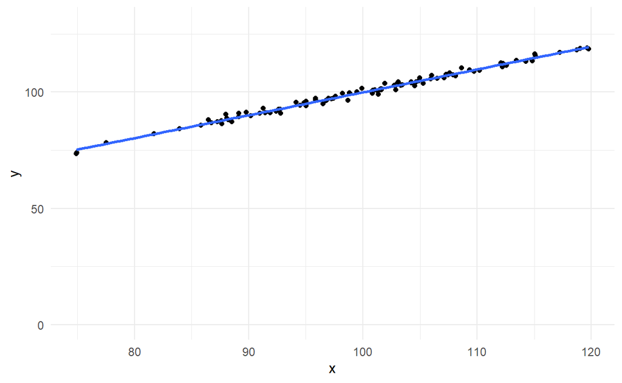

# A Regression *WITH* An Independent Variable

It’s worth remembering what a regression is trying to accomplish. Whether estimated via *OLS*, or *Maximum Likelihood*, a regression is–generally speaking–trying to find the line that best fits the data.

We know how the data was constructed, $y = 0 + 1 * x + e$, and a regression *WITH* an independent variable captures this relationship well.

Fitting linear model: y ~ x

|  | Estimate | Std. Error | t value | Pr(>\|t\|) |
| --- | --- | --- | --- | --- |
| **(Intercept)** | 1.514 | 1.009 | 1.502 | 0.1364 |
| **x** | 0.9841 | 0.01005 | 97.97 | 1.368e-99 |

# A Regression *WITHOUT* An Independent Variable

A regression *WITHOUT* an independent variable has a similar, but more difficult, task. This regression is trying to find a best fit to the data, with only a single constant parameter, $\beta_0$.

The blue line, the average, does the best job we can do of fitting a regression line with a single constant parameter, $\beta_0$. Any other constant line, e.g. the red line at 0, would not do such a good job of fitting the data.

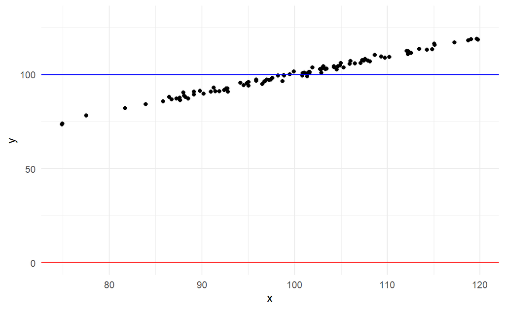

## Regression

We see this in the regression …

Fitting linear model: y ~ 1

|  | Estimate | Std. Error | t value | Pr(>\|t\|) |
| --- | --- | --- | --- | --- |
| **(Intercept)** | 99.85 | 0.9769 | 102.2 | 3.527e-102 |

## Mean

… which gives us the same value as the average.

*99.85*